# pre-assessment performance

## Introduction

This document looks at the model performance of the clinician predictions with a comparison against the MARS CHARTwatch model. The CHARTwatch model usually generates predictions 3 times a day, but for a fair comparison of clinician vs model predictions, we only run the CHARTwatch at times when the clincians generated their predictions.

## Descriptive statistics

Below is a breakdown of the number of predictions by professional role

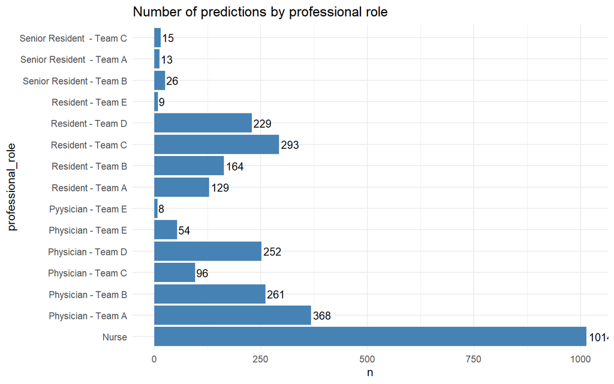

In total there were 68 patiens (8.8%) patients who experienced an outcome over the study period. There were 39 deaths, 29 ICU transfers and 30 palliative transfers.

## Performance of All Clincians

As a baseline check of model performance, we look at the accuracy of all clinician predictions against the outcome of death/icu/palliative transfer at any point in the patient stay. We can think of each clinician as its own model. This will mean multiple clinicians can predict on the same patient at the same time. Later we will look at average performance per clinician (and by role).

```r
library(caret)

cat("AUC of outcome at any time\n")
```

```
## AUC of outcome at any time
```

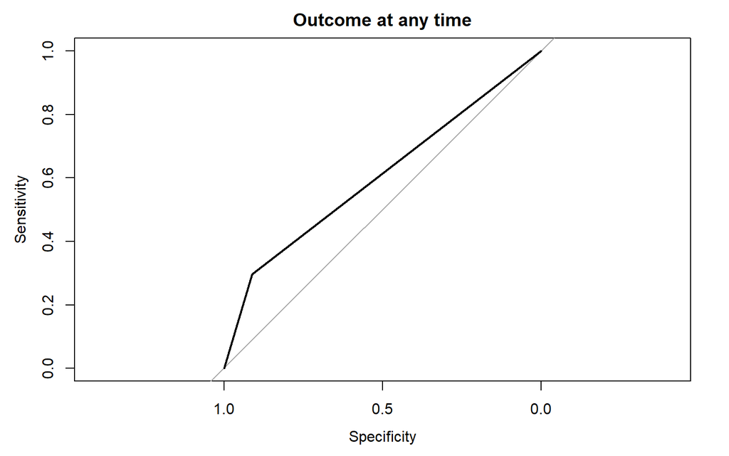

```r
roc_obj_ever <- roc(clinician$outcome, clinician$ever, plot=TRUE, ci=TRUE, main = "Outcome at any time")
```

```r
roc_obj_ever
```

```
##
## Call:
## roc.default(response = clinician$outcome, predictor = clinician$ever,     ci = TRUE, plot = TRUE, main = "Outcome at any time")
##
## Data: clinician$ever in 2550 controls (clinician$outcome 0) < 381 cases (clinician$outcome 1).
## Area under the curve: 0.6036
## 95% CI: 0.58-0.6272 (DeLong)
```

```r
cat("AUC of outcome in next 48 hours\n")
```

```
## AUC of outcome in next 48 hours
```

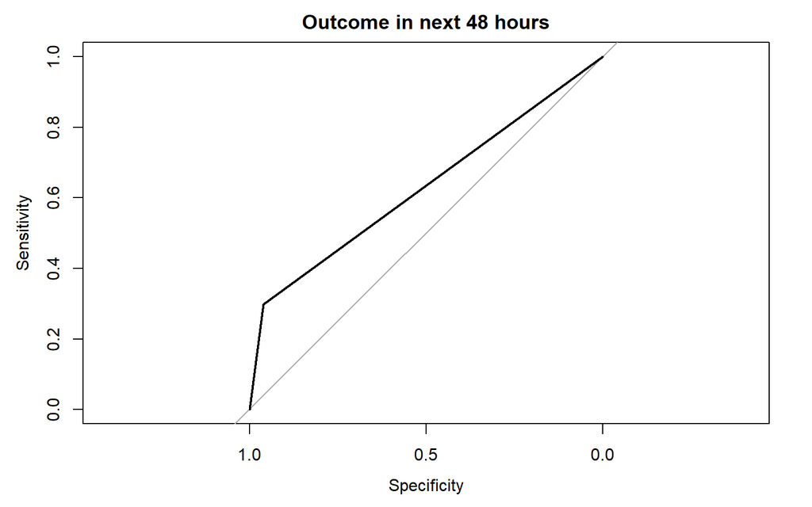

```r
roc_obj_ever <- roc(clinician$outcome48, clinician$next48, plot=TRUE, ci=TRUE, main = "Outcome in next 48 hours")
```

```r
roc_obj_ever
```

```
##
## Call:
## roc.default(response = clinician$outcome48, predictor = clinician$next48,     ci = TRUE, plot = TRUE, main = "Outcome in next 48 hours")
##
## Data: clinician$next48 in 2874 controls (clinician$outcome48 0) < 57 cases (clinician$outcome48 1).
## Area under the curve: 0.6293
## 95% CI: 0.5693-0.6893 (DeLong)
```

```r
confusionMatrix(factor(clinician$ever, levels = c(0, 1)), factor(clinician$outcome, levels = c(0,1)), positive = "1")
```

```
## Confusion Matrix and Statistics
##
##           Reference
## Prediction    0    1
##          0 2322  268
##          1  228  113
##
##                Accuracy : 0.8308
##                  95% CI : (0.8167, 0.8442)
##     No Information Rate : 0.87
##     P-Value [Acc > NIR] : 1.00000
##
##                   Kappa : 0.2169
##
##  Mcnemar's Test P-Value : 0.07992
##
##             Sensitivity : 0.29659
##             Specificity : 0.91059
##          Pos Pred Value : 0.33138
##          Neg Pred Value : 0.89653
##              Prevalence : 0.12999
##          Detection Rate : 0.03855
##    Detection Prevalence : 0.11634
##       Balanced Accuracy : 0.60359
##
##        'Positive' Class : 1
##
```

## Performance per clinician

In what follows we calculate performance metrics for each clinician and then examine those distributions to understand the average clinician performance. There are 169 clincians who provided at least 1 prediction with a median of 7 predictions per clinician (Interquartile Range: 4-16). Clincians provided predictions for a median of 7 patient encounters with an interquartile range of 4-15.

THere were 54 clinicians (31%) who’s patient never experienced an outcome. Of the remaining 115 clinicians, 63 (54.8%) did not correctly identify any outcomes (sensitivity). The plot below displays a histogram of sensitivities for each clinician (median = 0.0, IQR: 0.0 -.50). Eighteen clinicians had perfect sensitivity.

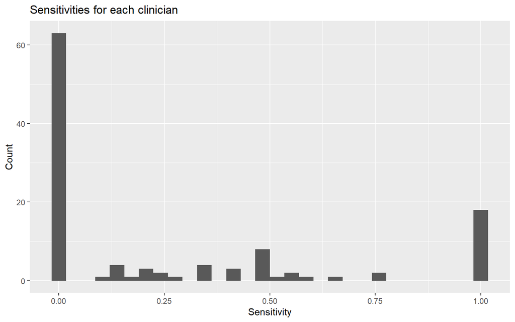

|  | role | number_clinicians | median_sens | q25_sens | q75_sens |
| --- | --- | --- | --- | --- | --- |
| 1 | Physician - Team E | 3 | 1 | 0.7 | 1 |
| 2 | Resident - Team A | 2 | 0.6 | 0.4 | 0.8 |
| 3 | Senior Resident - Team C | 1 | 0.521739130434783 | 0.521739130434783 | 0.521739130434783 |
| 4 | Physician - Team C | 3 | 0.5 | 0.321428571428571 | 0.75 |
| 5 | Resident - Team E | 1 | 0.5 | 0.5 | 0.5 |
| 6 | Physician - Team B | 4 | 0.416666666666667 | 0.25 | 0.508928571428571 |
| 7 | Senior Resident - Team B | 1 | 0.333333333333333 | 0.333333333333333 | 0.333333333333333 |
| 8 | Pyysician - Team E | 1 | 0.25 | 0.25 | 0.25 |
| 9 | Resident - Team B | 2 | 0.215811965811966 | 0.18482905982906 | 0.246794871794872 |
| 10 | Resident - Team C | 4 | 0.171428571428571 | 0.107142857142857 | 0.3375 |

[output cut: 5 more lines]

|  | role | number_clinicians | median_sens | q25_sens | q75_sens |
| --- | --- | --- | --- | --- | --- |
| 1 | Physician | 20 | 0.232142857142857 | 0 | 0.508928571428571 |
| 2 | Resident | 18 | 0.2 | 0.0357142857142857 | 0.5 |
| 3 | Nurse | 77 | 0 | 0 | 0.5 |

### PPV

THere were 67 clinicians (39.6%) that never made a positive prediction. Of the remaining 102 clinicians, 50 (49.0%) had a positive predictive value of 0. The plot below displays a histogram of positive predictive values for each clinician (median = 0.11, IQR: 0.0 -.50). Fourteen clinicians had perfect PPV.

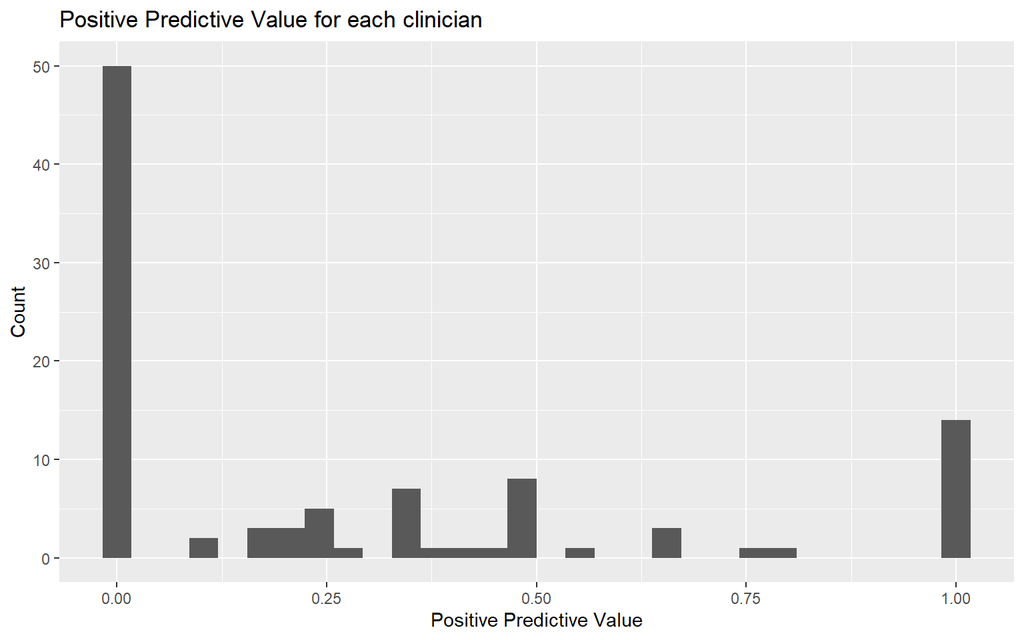

Below is a table of PPV performance by role (physician, resident, nurse). Residens have the highest PPV at 0.33 (IQR: 0.1 -.44)

|  | role | number_clinicians | median_ppv | q25_ppvs | q75_ppv |
| --- | --- | --- | --- | --- | --- |
| 1 | Resident | 17 | 0.333333333333333 | 0.1 | 0.444444444444444 |
| 2 | Physician | 18 | 0.267857142857143 | 0.125 | 0.458333333333333 |
| 3 | Nurse | 67 | 0 | 0 | 0.5 |

## Overall Model performance

Below we look at the AUC, sensitivity, and PPV of the model at the prediction level (as above for all clinicians). The AUC for the model predictions of an outcome at any time is 0.71 (95% CI: 0.67- 0.74%). The AUC for the model when the outcome occurs in the next 48 hours is 0.77 (95% CI: 0.70 - 0.85). The model has a sensitivity of 0.50 and a PPV of 0.31.

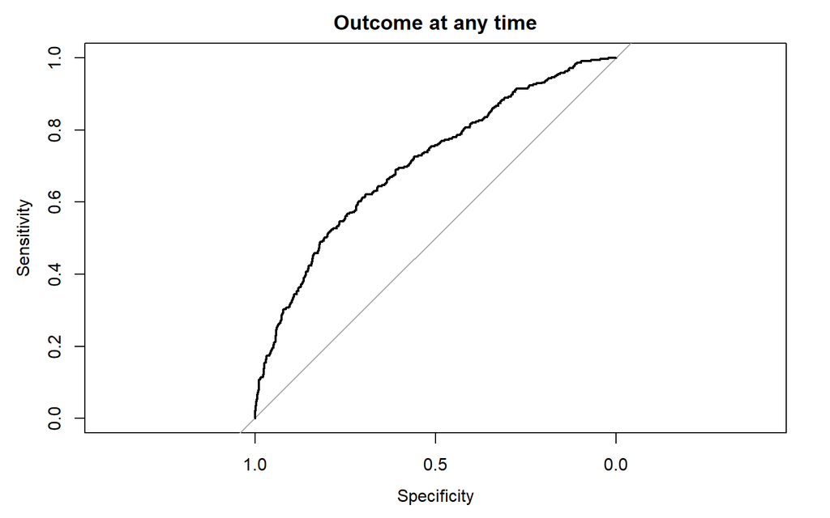

```
##
## Call:
## roc.default(response = model$outcome, predictor = model$last_score,     ci = TRUE, plot = TRUE, main = "Outcome at any time")
##
## Data: model$last_score in 1979 controls (model$outcome 0) < 351 cases (model$outcome 1).
## Area under the curve: 0.7058
## 95% CI: 0.6756-0.7359 (DeLong)
```

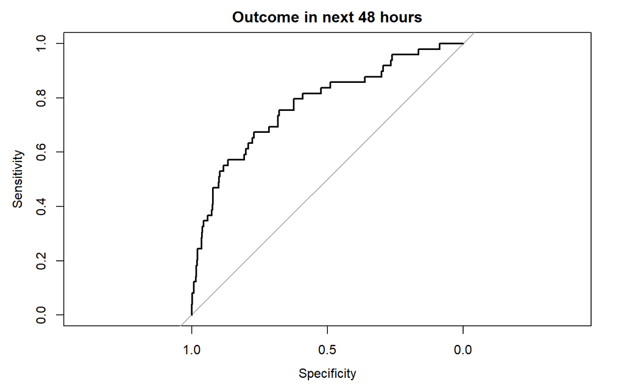

```
##
## Call:
## roc.default(response = model$outcome48, predictor = model$last_score,     ci = TRUE, plot = TRUE, main = "Outcome in next 48 hours")
##
## Data: model$last_score in 2281 controls (model$outcome48 0) < 49 cases (model$outcome48 1).
## Area under the curve: 0.7749
## 95% CI: 0.7024-0.8475 (DeLong)
```

```
## Confusion Matrix and Statistics
##
##           Reference
## Prediction    0    1
##          0 1595  175
##          1  384  176
##
##                Accuracy : 0.7601
##                  95% CI : (0.7422, 0.7773)
##     No Information Rate : 0.8494
##     P-Value [Acc > NIR] : 1
##
##                   Kappa : 0.2469
##
##  Mcnemar's Test P-Value : <2e-16
##
##             Sensitivity : 0.50142
##             Specificity : 0.80596
##          Pos Pred Value : 0.31429
##          Neg Pred Value : 0.90113
##              Prevalence : 0.15064
##          Detection Rate : 0.07554
##    Detection Prevalence : 0.24034
##       Balanced Accuracy : 0.65369
##
##        'Positive' Class : 1
##
```